# Introducción a la estadística con R

Amílcar José Escobedo Pérez

## Sesión 1: Instalando R y RStudio

Antes de comenzar a ver aplicaciones vamos a aprender a instalar **R** y **R studio**.

**R** es un lenguaje de programación que se desarrolló precisamente para aplicaciones estadísticas y es un software de código abierto lo que quiere decir que cualquiera puede descargarlo sin ningún costo modificarlo, distribuirlo y crear sus propios paquetes y compartirlos. **R studio** es una aplicación qué sirve para crear y editar de manera más eficiente scripts de **R** también otro tipo de documentos que incluyan código de **R** o simplemente html e incluso LaTeX.

#### Para instalar **R** ir a la siguiente página:

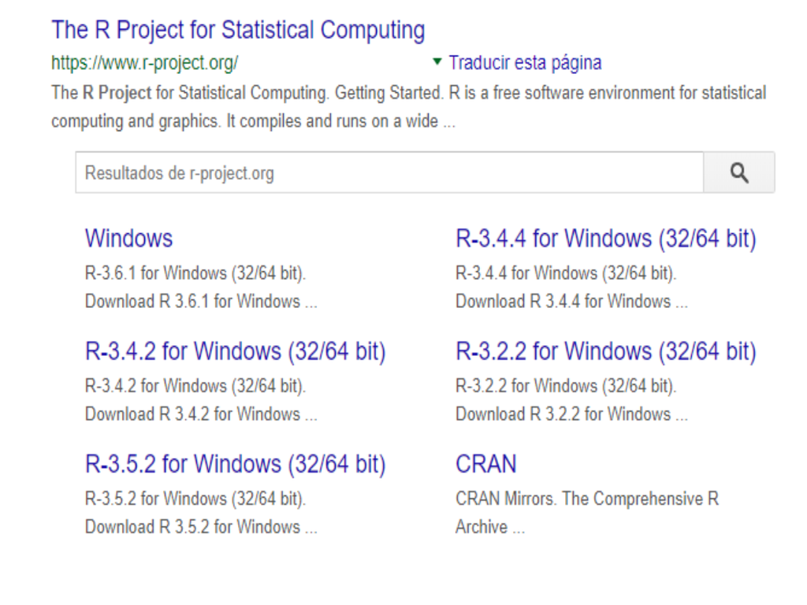

#### Ahora, para instalar **R Studio** ir a:

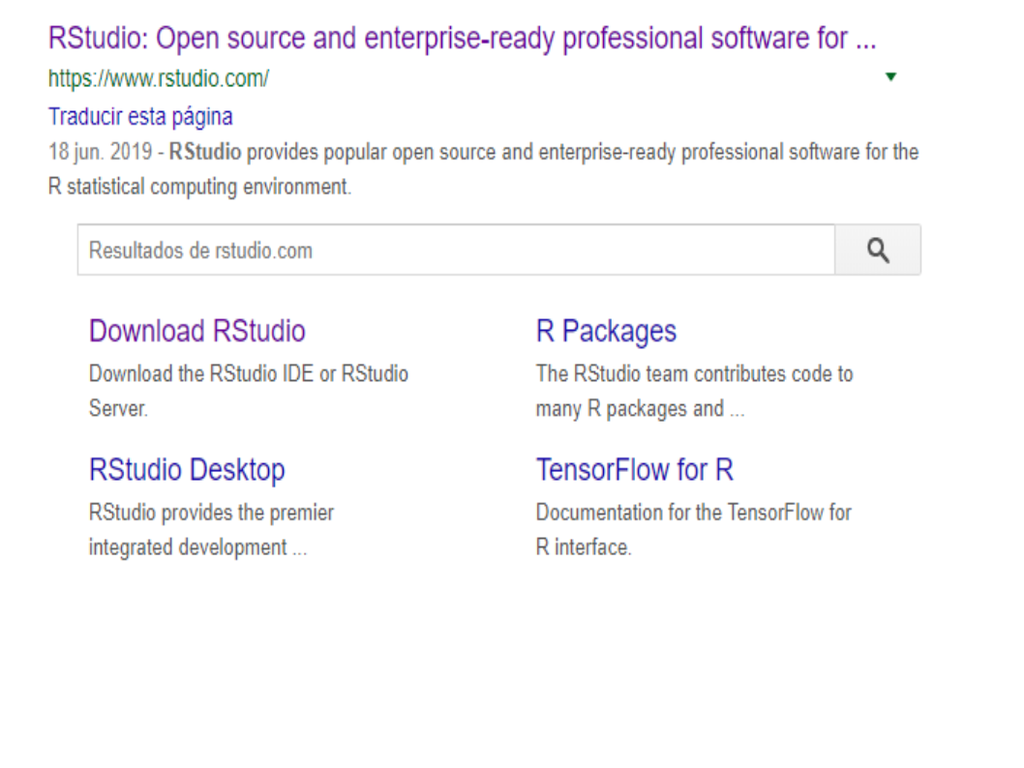

### Descargar y llamar paquetes:

Una vez que ya se tiene instalado **R** y **R Studio** en la máquina lo que sigue es aprender a descargar librerías y paquetes al entorno de trabajo.

La forma de descargar un paquete o una librería es mediante la función install package y entre paréntesis y comillas escribir el nombre del paquete o librería que Uno desea instalar.

Asi

```r
install.packages("stats")
```

Para llamar un paquete al entrono de trabajo:

```r
require(stats)
```

#### Paquetes útiles

Los siguiente son paquetes que usaremos próximamente:

- **dplyr**
- **stats**
- **snpar**
- **BSDA**
- **randtests**

Para obtener información a cerca de un paquete ya descargado:

```r
library(help = "stats")
```

#### Asignar valores y operar con variables

```r
x<-c(1,2,3)
x
```

```
## [1] 1 2 3
```

```r
y=c(1,2,3,4)
y
```

```
## [1] 1 2 3 4
```

```r
z<-c(4:6)
z
```

```
## [1] 4 5 6
```

```r
x*z
```

```
## [1]  4 10 18
```

```r
x+z
```

```
## [1] 5 7 9
```

```r
z/x
```

```
## [1] 4.0 2.5 2.0
```

```r
exp(x)
```

```
## [1]  2.718282  7.389056 20.085537
```

```r
t(x)%*%z
```

```
##      [,1]
## [1,]   32
```

```r
x%*%t(z)
```

```
##      [,1] [,2] [,3]
## [1,]    4    5    6
## [2,]    8   10   12
## [3,]   12   15   18
```

#### Distribuciones de Probabilidad

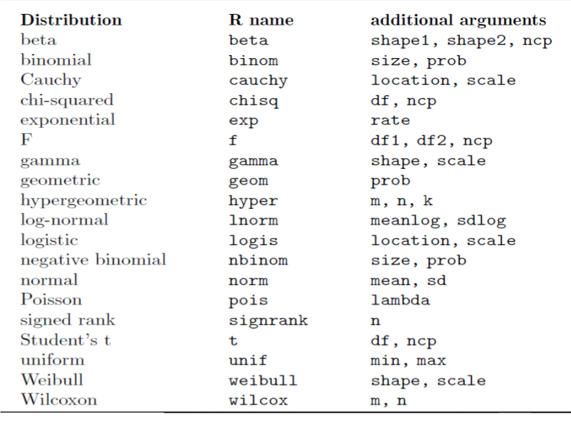

A continuación se muestra un ejemplo de cómo generar muestras de distribuciones, calcular PDF’s y CDF’s para variables aleatorias:

```r
rbinom(10,3,0.5)
```

```
##  [1] 2 2 1 2 2 2 0 2 1 3
```

```r
rnorm(4,mean = 15,sd = 2)
```

```
## [1] 14.60938 11.44010 12.49539 15.72774
```

```r
pnorm(15,mean = 15,sd = 2)
```

```
## [1] 0.5
```

```r
dnorm(15,mean = 15,sd = 2)
```

```
## [1] 0.1994711
```

#### Análisis preliminar y visualización de datos

```r
x<-rexp(20,rate = 1/5)
x
```

```
##  [1]  3.9696982  0.0586405  1.4717858  0.3842207  0.6399398  4.6814823
##  [7] 10.8072840 10.2262863  4.0730886  7.6934921  2.7675946  0.4222121
## [13]  6.9804549  1.7173850  0.5571560 11.2543932  6.0793666  2.7219240
## [19] 31.1457997  3.6691883
```

```r
summary(x)
```

```
##     Min.  1st Qu.   Median     Mean  3rd Qu.     Max.
##  0.05864  1.26382  3.81944  5.56607  7.15871 31.14580
```

```r
mean(x)
```

```
## [1] 5.56607
```

```r
var(x)
```

```
## [1] 49.06896
```

```r
quantile(x,probs = c(0.5,0.75))
```

```
##      50%      75%
## 3.819443 7.158714
```

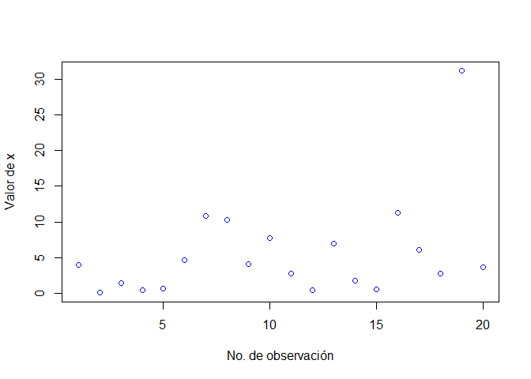

```r
plot(x,ylab = "Valor de x",xlab = "No. de observación",col="blue")
```

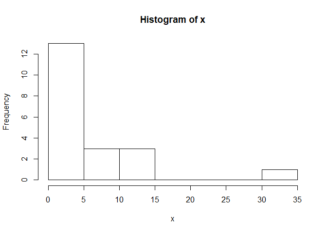

```r
hist(x)
```

**Tip para la vida:** Para hacer el análisis preliminar de bases de datos grandes usar **DataExplorer**.

```r
require(DataExplorer)
```